# Detecting Anomalous COVID-19 Reporting Patterns

Exploratory Analysis and K-Means Clustering

# 1 Introduction

## 1.1 Research Objective

The objective of this project is to identify unusual geographical COVID-19 activity using exploratory visualization and K-Means clustering.

The analysis addresses the following questions:

1. Which countries have unusually high reported death-to-case ratios?
2. Which US states experienced the largest single-day case increases per 100,000 residents?
3. Can countries be grouped according to their cumulative COVID-19 death-to-case ratios

## 1.2 Requirements

Required Packages:

- tidyverse
- tidymodels
- tidyclust

set.seed(100)

# 2 Data

## 2.1 Data Source

The data used in this project were published by the Johns Hopkins University through its COVID-19 GitHub repository.

Four datasets are included in the analysis:

Global Confirmed Cases Global Deaths US Confirmed Cases US Deaths

## 2.2 Reproducible Data Import

All objects used in this report are created when the document is knitted.

```r
url_in <- "https://raw.githubusercontent.com/CSSEGISandData/COVID-19/master/csse_covid_19_data/csse_covid_19_time_series/"

file_names <- c(
  "time_series_covid19_confirmed_US.csv",
  "time_series_covid19_confirmed_global.csv",
  "time_series_covid19_deaths_US.csv",
  "time_series_covid19_deaths_global.csv"
)

urls <- str_c(url_in, file_names)

confirmed_us_url     <- urls[1]
confirmed_global_url <- urls[2]
deaths_us_url        <- urls[3]
deaths_global_url    <- urls[4]

confirmed_us_raw <- read_csv(
  confirmed_us_url,
  show_col_types = FALSE
)

confirmed_global_raw <- read_csv(
  confirmed_global_url,
  show_col_types = FALSE
)

deaths_us_raw <- read_csv(
  deaths_us_url,
  show_col_types = FALSE
)

deaths_global_raw <- read_csv(
  deaths_global_url,
  show_col_types = FALSE
)
```

# 3 Data Preparation

The original Johns Hopkins datasets use a wide format in which each date is stored in a separate column. The data were converted into a long format with one row per geographic unit and date.

## 3.1 Data Cleaning

The main steps were:

1. Convert date columns from wide to long format.
2. Convert date values into R date objects.
3. Aggregate records to the state level.
4. Aggregate records to the country level.
5. Join confirmed-case and death records.
6. Calculate daily values from cumulative totals.
7. Calculate population-adjusted US case rates.

```r
# Clean US confirmed cases -------------------------------------

confirmed_us_clean <- confirmed_us_raw %>%
  pivot_longer(
    cols = -c(
      UID,
      iso2,
      iso3,
      code3,
      FIPS,
      Admin2,
      Province_State,
      Country_Region,
      Lat,
      Long_,
      Combined_Key
    ),
    names_to = "date",
    values_to = "confirmed"
  ) %>%
  mutate(
    date = mdy(date)
  ) %>%
  group_by(
    state = Province_State,
    country = Country_Region,
    date
  ) %>%
  summarize(
    confirmed = sum(confirmed, na.rm = TRUE),
    .groups = "drop"
  ) %>%
  arrange(
    country,
    state,
    date
  )


# Clean global confirmed cases --------------------------------------------

confirmed_global_clean <- confirmed_global_raw %>%
  pivot_longer(
    cols = -c(
      `Province/State`,
      `Country/Region`,
      Lat,
      Long
    ),
    names_to = "date",
    values_to = "confirmed"
  ) %>%
  mutate(
    date = mdy(date)
  ) %>%
  group_by(
    country = `Country/Region`,
    date
  ) %>%
  summarize(
    confirmed = sum(confirmed, na.rm = TRUE),
    .groups = "drop"
  ) %>%
  arrange(
    country,
    date
  )

# Clean United States deaths ----------------------------------------------

deaths_us_clean <- deaths_us_raw %>%
  pivot_longer(
    cols = -c(
      UID,
      iso2,
      iso3,
      code3,
      FIPS,
      Admin2,
      Province_State,
      Country_Region,
      Lat,
      Long_,
      Combined_Key,
      Population
    ),
    names_to = "date",
    values_to = "deaths"
  ) %>%
  mutate(
    date = mdy(date)
  ) %>%
  group_by(
    state = Province_State,
    country = Country_Region,
    date
  ) %>%
  summarize(
    deaths = sum(deaths, na.rm = TRUE),
    population = sum(Population, na.rm = TRUE),
    .groups = "drop"
  ) %>%
  arrange(
    country,
    state,
    date
  )

# Clean global deaths ------------------------------------------------------

deaths_global_clean <- deaths_global_raw %>%
  pivot_longer(
    cols = -c(
      `Province/State`,
      `Country/Region`,
      Lat,
      Long
    ),
    names_to = "date",
    values_to = "deaths"
  ) %>%
  mutate(
    date = mdy(date)
  ) %>%
  group_by(
    country = `Country/Region`,
    date
  ) %>%
  summarize(
    deaths = sum(deaths, na.rm = TRUE),
    .groups = "drop"
  ) %>%
  arrange(
    country,
    date
  )

# Combine global confirmed cases and deaths -------------------------------

covid_global_clean <- confirmed_global_clean %>%
  full_join(
    deaths_global_clean,
    by = c("country", "date")
  ) %>%
  arrange(
    country,
    date
  )

# Combine United States confirmed cases and deaths ------------------------

covid_us_clean <- confirmed_us_clean %>%
  full_join(
    deaths_us_clean,
    by = c("state", "country", "date")
  ) %>%
  arrange(
    country,
    state,
    date
  )

# Check combined datasets --------------------------------------------------

glimpse(covid_global_clean)
```

```
## Rows: 229,743
## Columns: 4
## $ country   <chr> "Afghanistan", "Afghanistan", "Afghanistan", "Afghanistan", …
## $ date      <date> 2020-01-22, 2020-01-23, 2020-01-24, 2020-01-25, 2020-01-26,…
## $ confirmed <dbl> 0, 0, 0, 0, 0, 0, 0, 0, 0, 0, 0, 0, 0, 0, 0, 0, 0, 0, 0, 0, …
## $ deaths    <dbl> 0, 0, 0, 0, 0, 0, 0, 0, 0, 0, 0, 0, 0, 0, 0, 0, 0, 0, 0, 0, …
```

```r
glimpse(covid_us_clean)
```

```
## Rows: 66,294
## Columns: 6
## $ state      <chr> "Alabama", "Alabama", "Alabama", "Alabama", "Alabama", "Ala…
## $ country    <chr> "US", "US", "US", "US", "US", "US", "US", "US", "US", "US",…
## $ date       <date> 2020-01-22, 2020-01-23, 2020-01-24, 2020-01-25, 2020-01-26…
## $ confirmed  <dbl> 0, 0, 0, 0, 0, 0, 0, 0, 0, 0, 0, 0, 0, 0, 0, 0, 0, 0, 0, 0,…
## $ deaths     <dbl> 0, 0, 0, 0, 0, 0, 0, 0, 0, 0, 0, 0, 0, 0, 0, 0, 0, 0, 0, 0,…
## $ population <dbl> 4903185, 4903185, 4903185, 4903185, 4903185, 4903185, 49031…
```

```r
# Calculate daily global values -------------------------------------------

covid_global_clean <- covid_global_clean %>%
  group_by(country) %>%
  arrange(date, .by_group = TRUE) %>%
  mutate(
    daily_cases = confirmed - lag(confirmed),
    daily_deaths = deaths - lag(deaths)
  ) %>%
  ungroup()

# Calculate daily United States values ------------------------------------

covid_us_clean <- covid_us_clean %>%
  group_by(country, state) %>%
  arrange(date, .by_group = TRUE) %>%
  mutate(
    daily_cases = confirmed - lag(confirmed),
    daily_deaths = deaths - lag(deaths)
  ) %>%
  ungroup()
```

## 3.2 Data Summaries

Result of Data Cleaning

| Dataset | Rows | Columns | Geographic units | First date | Last date |
| --- | --- | --- | --- | --- | --- |
| US confirmed cases | 66,294 | 4 | 58 | 2020-01-22 | 2023-03-09 |
| Global confirmed cases | 229,743 | 3 | 201 | 2020-01-22 | 2023-03-09 |
| US deaths | 66,294 | 5 | 58 | 2020-01-22 | 2023-03-09 |
| Global deaths | 229,743 | 3 | 201 | 2020-01-22 | 2023-03-09 |

## 3.3 Data Validation

Result of Data Validation

| Dataset | Geographic units | First date | Last date | Missing confirmed | Missing deaths | Negative daily cases | Negative daily deaths |
| --- | --- | --- | --- | --- | --- | --- | --- |
| Global | 201 | 2020-01-22 | 2023-03-09 | 0 | 0 | 171 | 199 |
| United States | 58 | 2020-01-22 | 2023-03-09 | 0 | 0 | 136 | 325 |

Daily case values can occasionally be negative because cumulative case totals are sometimes revised downward. These values were retained because historical corrections are meaningful and incorporated into the Kmeans Cluster Model.

# 4 Exploratory Data Analysis

## 4.1 Country Death-to-Case Ratios

The first exploratory analysis examines cumulative deaths as a percentage of confirmed cases. The ratio is calculated for each country using the final date available in the dataset.

Using IQR method to define anomaly boundaries, the countries that are beyond 1.5 IQR are isolated

```r
# total deaths case ratio by country

latest_global_date <- max(covid_global_clean$date, na.rm = TRUE)

country_death_case_ratio <- covid_global_clean %>%
  filter(date == latest_global_date) %>%
  filter(
    !is.na(confirmed),
    !is.na(deaths),
    confirmed > 0
  ) %>%
  mutate(
    death_case_ratio = deaths / confirmed,
    death_case_percent = death_case_ratio * 100
  )

minimum_confirmed_cases <- 100000

country_death_case_ratio <- country_death_case_ratio %>%
  filter(confirmed >= minimum_confirmed_cases)

top_death_case_countries <- country_death_case_ratio %>%
  select(
    country,
    confirmed,
    deaths,
    death_case_percent
  ) %>%
  arrange(desc(death_case_percent)) %>%
  slice_head(n = 10)

knitr::kable(
  top_death_case_countries,
  col.names = c(
    "Country",
    "Confirmed cases",
    "Deaths",
    "Death-case percent"
  ),
  caption = "Countries with the highest reported death-to-case percentages",
  digits = c(0, 0, 0, 2),
  format.args = list(
    big.mark = ","
  )
)
```

Countries with the highest reported death-to-case percentages

| Country | Confirmed cases | Deaths | Death-case percent |
| --- | --- | --- | --- |
| Peru | 4,487,553 | 219,539 | 4.89 |
| Egypt | 515,759 | 24,812 | 4.81 |
| Mexico | 7,483,444 | 333,188 | 4.45 |
| Bosnia and Herzegovina | 401,729 | 16,280 | 4.05 |
| Afghanistan | 209,451 | 7,896 | 3.77 |
| Ecuador | 1,057,121 | 36,014 | 3.41 |
| Burma | 633,950 | 19,490 | 3.07 |
| Bulgaria | 1,297,523 | 38,228 | 2.95 |
| North Macedonia | 346,852 | 9,662 | 2.79 |
| Tunisia | 1,151,126 | 29,341 | 2.55 |

```r
# Use IQR to identify countries with anomalous ratios

ratio_q1 <- quantile(
  country_death_case_ratio$death_case_percent,
  0.25,
  na.rm = TRUE
)

ratio_q3 <- quantile(
  country_death_case_ratio$death_case_percent,
  0.75,
  na.rm = TRUE
)

ratio_iqr <- ratio_q3 - ratio_q1

upper_ratio_limit <- ratio_q3 + 1.5 * ratio_iqr

death_case_ratio_anomalies <- country_death_case_ratio %>%
  filter(death_case_percent > upper_ratio_limit) %>%
  select(
    country,
    confirmed,
    deaths,
    death_case_percent
  ) %>%
  arrange(desc(death_case_percent))

knitr::kable(
  death_case_ratio_anomalies,
  col.names = c(
    "Country",
    "Confirmed cases",
    "Deaths",
    "Death-case percent"
  ),
  caption = "Countries above the 1.5 × IQR death-to-case threshold",
  digits = c(0, 0, 0, 2),
  format.args = list(
    big.mark = ","
  )
)
```

Countries above the 1.5 × IQR death-to-case threshold

| Country | Confirmed cases | Deaths | Death-case percent |
| --- | --- | --- | --- |
| Peru | 4,487,553 | 219,539 | 4.89 |
| Egypt | 515,759 | 24,812 | 4.81 |
| Mexico | 7,483,444 | 333,188 | 4.45 |
| Bosnia and Herzegovina | 401,729 | 16,280 | 4.05 |

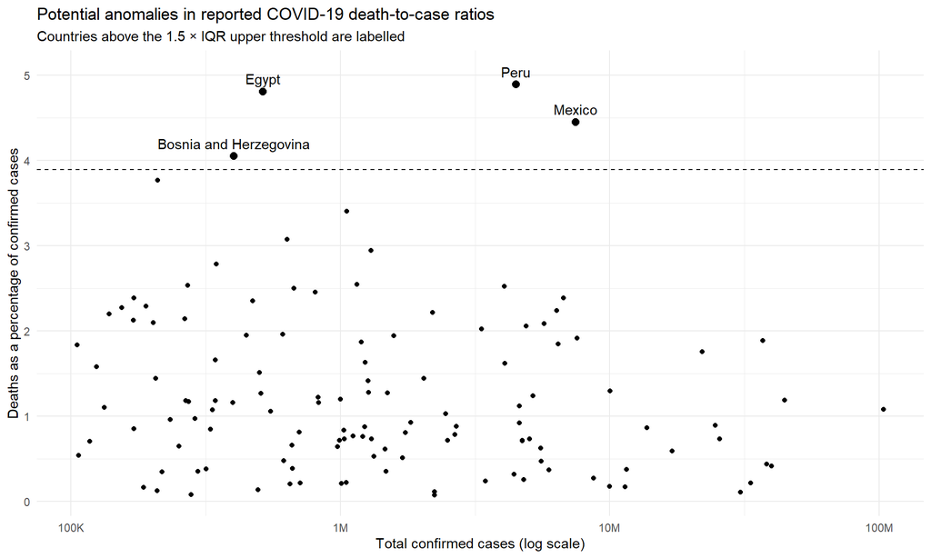

Reported cumulative deaths as a proportion of confirmed cases by country.

Egypt, Peru, Mexico, and Bosnia and Herzegovina were the 4 countries above the 1.5 IQR boundary and would require further analysis to understand the characteristics of pandemic management in those countries or if there are any unusual reporting methodologies implemented.

## 4.2 Largest Case Spikes in US States

The second exploratory analysis identifies the four US states with the largest reported single-day case increases per 100,000 residents.

Regions with populations of 500,000 or fewer were excluded as the datasets included minor overseas territories and cruise ships.

```r
# US states and population

state_populations <- covid_us_clean %>%
  distinct(state, population) %>%
  arrange(desc(population))

# Based on US states and population, cut off for true states is 500,000

# States with largest daily spikes per 100,000

covid_us_explore <- covid_us_clean %>%
  filter(population >= 500000) %>%
  mutate(
    daily_cases_per_100k = (daily_cases / population) * 100000
  )

largest_state_outbreaks <- covid_us_explore %>%
  group_by(state) %>%
  summarize(
    max_daily_cases_per_100k = max(
      daily_cases_per_100k,
      na.rm = TRUE
    ),
    .groups = "drop"
  ) %>%
  arrange(desc(max_daily_cases_per_100k)) %>%
  slice_head(n = 4)

knitr::kable(
  largest_state_outbreaks,
  col.names = c(
    "State",
    "Maximum daily cases per 100,000"
  ),
  caption = "States with the largest population-adjusted single-day case spikes",
  digits = 2,
  format.args = list(
    big.mark = ","
  )
)
```

States with the largest population-adjusted single-day case spikes

| State | Maximum daily cases per 100,000 |
| --- | --- |
| Rhode Island | 1,531.87 |
| Wisconsin | 1,428.73 |
| South Carolina | 1,407.05 |
| Alaska | 1,375.72 |

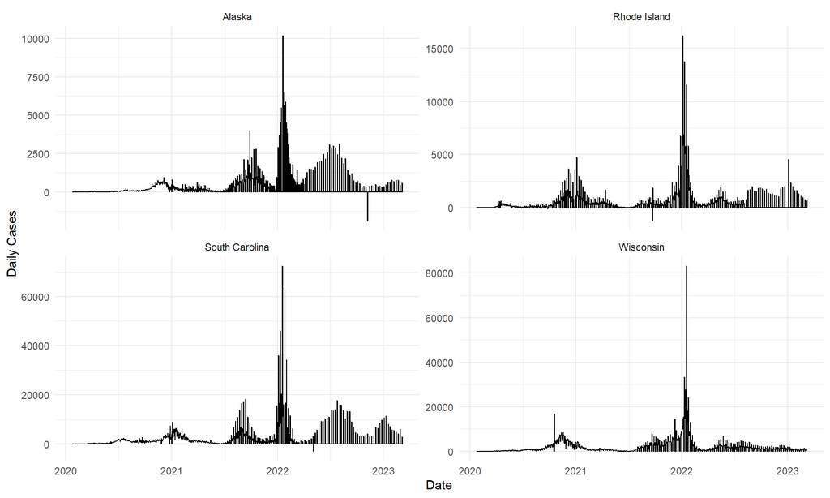

The four largest single-day spikes all occurred during January 2022. Additional headline search during that period revealed that the shared timing is likely associated with the highly contagious Omicron variant wave rather than four unrelated outbreaks.

However, adjusted for population these four states still had the largest spikes during that time and would benefit from further assessment of their public health efforts

# 5 Modeling - K-Means

## 5.1 Model Rationale

The objective of this model is to provide further analysis on the death to cases ratio anomaly detection previously conducted through IQR outliers.

K-Means is an unsupervised machine-learning method that groups observations according to their similarity across numerical features.

An unsupervised method is appropriate for this because the dataset does not contain labels indicating whether a country is normal or anomalous based on their death and case rates.

Countries that are substantially different from the majority, or that are unusually distant from the centre of their assigned cluster can be identified as candidates for further investigation.

## 5.2 Feature Engineering

K-Means requires one row for each observation being clustered. The global dataset contains repeated daily observations for each country so the data needs to be aggregated into country-level features.

```r
# Create country-level features ------------------------------------

# Latest date

latest_global_date <- max(
  covid_global_clean$date,
  na.rm = TRUE
)

# Latest cumulative totals by country

latest_country_totals <- covid_global_clean %>%
  filter(date == latest_global_date) %>%
  select(
    country,
    confirmed,
    deaths
  )

# Daily reporting features

country_daily_features <- covid_global_clean %>%
  group_by(country) %>%
  summarize(
    max_daily_cases = max(
      daily_cases,
      na.rm = TRUE
    ),
    sd_daily_cases = sd(
      daily_cases,
      na.rm = TRUE
    ),
    negative_case_corrections = sum(
      daily_cases < 0,
      na.rm = TRUE
    ),
    .groups = "drop"
  )

# Combine country-level features

country_anomaly_features <- latest_country_totals %>%
  inner_join(
    country_daily_features,
    by = "country"
  ) %>%
  filter(
    !is.na(confirmed),
    !is.na(deaths),
    confirmed >= 100000
  ) %>%
  mutate(
    death_case_ratio = deaths / confirmed,
    death_case_percent = death_case_ratio * 100
  )
```

The dataset does not include country populations, so focusing primarily on death-case ratio will shift the focus more on policy, reporting methods, and less so on overall raw size of deaths and cases.

## 5.3 Feature Standardization

The numerical features have substantially different scales so standardization was applied before fitting

```r
country_cluster_recipe <- recipe(
  ~ .,
  data = country_anomaly_features
) %>%
  update_role(
    country,
    new_role = "id"
  ) %>%
  step_log(
    confirmed,
    deaths,
    max_daily_cases,
    offset = 1
  ) %>%
  step_normalize(
    all_numeric_predictors()
  )
```

## 5.4 Number of Clusters

Several candidate values of k were tested using total within-cluster variance and then selected using the Elbow Method

K-Means performance across candidate cluster counts

| Number of clusters | Total within-cluster sum of squares |
| --- | --- |
| 2 | 592.47 |
| 3 | 446.58 |
| 4 | 362.17 |
| 5 | 304.64 |
| 6 | 260.17 |
| 7 | 231.04 |
| 8 | 203.56 |

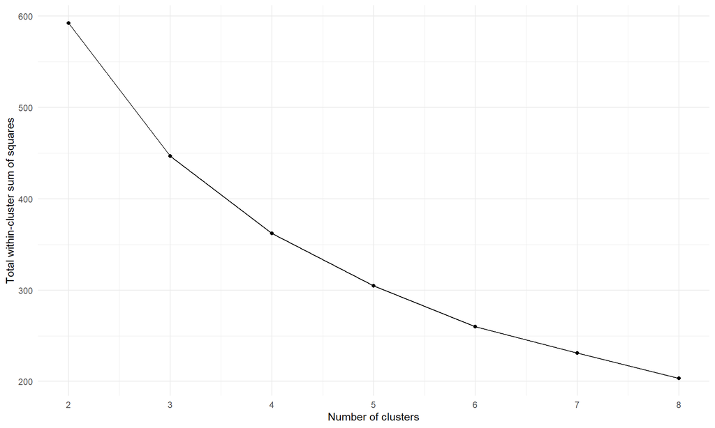

Elbow Method for selecting candidate K-Means clusters

```r
# Prepare data for k-means

country_cluster_prepped <- country_cluster_recipe %>%
  prep()

country_cluster_processed <- country_cluster_prepped %>%
  bake(
    new_data = NULL
  )

# Remove ID column

country_cluster_data <- country_cluster_processed %>%
  select(-country)


# evaluate clusters performance

set.seed(100)

cluster_comparison <- tibble(
  clusters = 2:8,
  total_withinss = map_dbl(
    2:8,
    ~ kmeans(
      country_cluster_data,
      centers = .x,
      nstart = 25
    )$tot.withinss
  )
)

knitr::kable(
  cluster_comparison,
  col.names = c(
    "Number of clusters",
    "Total within-cluster sum of squares"
  ),
  caption = "K-Means performance across candidate cluster counts",
  digits = 2,
  format.args = list(
    big.mark = ","
  )
)
```

The within-cluster variance decreases sharply between 2-4 clusters, after which the improvements became more gradual.

## 5.5 Final Model

The selected value of k = 4 is passed through the k_means tidymodels spec and workflow, then fitted using the selected features

```r
# Specify k-means model

country_kmeans_spec <- k_means(
  num_clusters = 4
) %>%
  set_engine(
    "stats",
    nstart = 25
  )


# create workflow

country_kmeans_workflow <- workflow() %>%
  add_recipe(
    country_cluster_recipe
  ) %>%
  add_model(
    country_kmeans_spec
  )

# fit model

set.seed(100)

country_kmeans_fit <- country_kmeans_workflow %>%
  fit(
    data = country_anomaly_features
  )
```

## 5.6 Assigning to Clusters

Countries were then assigned to clusters and each cluster’s characteristics were tabulated

```r
# Cluster assignment

country_cluster_results <- augment(
  country_kmeans_fit,
  new_data = country_anomaly_features
)
```

Summary statistics for each K-Means cluster

| Cluster | Number of countries | Median confirmed cases | Median deaths | Median death-case percent | Median maximum daily cases | Median SD of daily cases | Median negative corrections |
| --- | --- | --- | --- | --- | --- | --- | --- |
| Cluster_1 | 27 | 515759 | 16280.0 | 2.46 | 11366 | 805.12 | 0 |
| Cluster_2 | 51 | 507187 | 3155.0 | 0.81 | 7408 | 877.86 | 0 |
| Cluster_3 | 36 | 4673219 | 25820.5 | 0.80 | 56684 | 7391.23 | 1 |
| Cluster_4 | 13 | 30615522 | 168935.0 | 0.74 | 454212 | 40865.77 | 1 |

## 5.7 Cluster Visualization

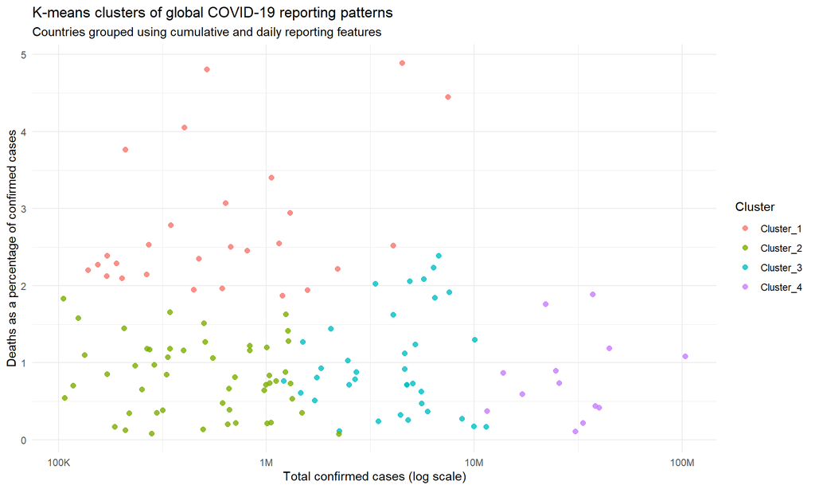

Country groupings produced by the four-cluster K-Means model.

## 5.8 Distance from Cluster Centre

Based on the cluster assignments, euclidian distances were calculated for each country from the cluster centres

## 5.9 Potential Anomalies Within Cluster 1

Cluster 1 is the group with the highest deaths-case ratio and countries that are unusually far from the centre within this cluster may represent potential anomalies for the dataset

Applying the 1.5 IQR rule to the cluster, we narrow down to the countries with the most unusual death-case ratios.

```r
# Cluster 1 countries ranked by distance from centre

cluster_1_distance_table <- country_cluster_results %>%
  filter(
    .pred_cluster == "Cluster_1"
  ) %>%
  arrange(
    desc(distance_from_centre)
  ) %>%
  select(
    country,
    confirmed,
    deaths,
    death_case_percent,
    max_daily_cases,
    sd_daily_cases,
    negative_case_corrections,
    distance_from_centre
  )

# Identify potential anomalies within Cluster 1

cluster_1_distance_q1 <- quantile(
  cluster_1_distance_table$distance_from_centre,
  0.25,
  na.rm = TRUE
)

cluster_1_distance_q3 <- quantile(
  cluster_1_distance_table$distance_from_centre,
  0.75,
  na.rm = TRUE
)

cluster_1_distance_iqr <-
  cluster_1_distance_q3 -
  cluster_1_distance_q1

cluster_1_distance_limit <-
  cluster_1_distance_q3 +
  1.5 * cluster_1_distance_iqr

cluster_1_distance_table <- cluster_1_distance_table %>%
  mutate(
    potential_anomaly =
      distance_from_centre >
      cluster_1_distance_limit
  ) %>%
  arrange(
    desc(potential_anomaly),
    desc(distance_from_centre)
  )
```

Potential anomalies within Cluster 1

| Country | Confirmed cases | Deaths | Death-case percent | Maximum daily cases | SD of daily cases | Negative corrections | Distance from centre | Potential anomaly |
| --- | --- | --- | --- | --- | --- | --- | --- | --- |
| Peru | 4,487,553 | 219,539 | 4.89 | 67,101 | 7,368.44 | 10 | 6.052 | TRUE |
| Mexico | 7,483,444 | 333,188 | 4.45 | 109,895 | 10,477.27 | 5 | 4.245 | TRUE |

The result shows that Peru and Mexico qualify as anomalies in both the simple IQR analysis as well as the K-Means cluster analysis. This gives additional support that the public health policies and reporting methods should be studied to prevent future pandemic response from reaching this level of escalation

# 6 Bias Identification

The data may contain biases stemming from multiple sources.

Testing and measurement methods:

Confirmed cases depend on testing availability and public willingness to take the tests. Countries that conducted more tests may report more cases

Death reporting qualification:

Definition of a COVID-19 death differs between countries and changed during the pandemic

Timing lag:

Daily cases represent the date when cases were reported rather than the exact date of infection Weekeneds and holidays as well a lab delays,and data ingestion issues can all contribute to artificial daily spikes or adjustments

Population bias:

Countries with higher population will likely report higher confirmed cases.  
Differences in age distribution, population densities, and start of pandemic timing will all impact reporting

# 7 Conclusion

This project developed a reproducible workflow for importing, cleaning, exploring, and modeling COVID-19 time-series data from the Johns Hopkins University GitHub repository.

The analysis demonstrates that unsupervised learning can help identify unusual observations when verified anomaly labels are unavailable. However, statistical anomalies should not automatically be interpreted as problematic candidates. Testing practice and capacity differences, demographic differences, and differences in reporting systems all influence the observed results.